# CRANvignette_statgenGWAS

Bailey Kretzler

8/10/2021

ALL REPHRASED FROM CRAN VINGETTE SOLELY FOR LEARNING PURPOSES

[CRAN vingette](https://cran.r-project.org/web/packages/statgenGWAS/vignettes/GWAS.html)

[Author Github](https://github.com/Biometris/statgenGWAS/)

## gData data class

gData stands for genomic data and is a class of data that can be used with the statgenGWAS package. And maybe others but I am entirely unsure about that. this is where you should start with your data. Multiple components of your data set can be input into this data class and data can be added later on. The function `createGData` will convert the data you give it to a gData object if you input it in the correct format. This code snippet demonstrates the use of this function.

```r
#------------------converting to gData-----------------------#

#gDataDrops <- createGData(geno = dropsMarkers,
                          #map = dropsMap,
                          #pheno = dropsPhenoList)
```

### components of a gData object

*Marker Map*

this is where the markers or SNPs are on the chromosome. In the drops example, this data frame consists of SNP names, chromosome numbers, locations, and alleles for that SNP (change in base pair that occurs). Before puting this into createGData, the row names need to become the SNP names. chromosomes should be labeled as chr, position on the chromosome should be label pos. The code chunk below examines the marker map from the drops data and converts it to the appropriate format.

```r
### dropsMap ###

#rownames <- snp names
rownames(dropsMap) <- dropsMap$SNP.names

#rename chromosome and position columns
dropsMap = dropsMap %>%
  rename(chr = Chromosome, pos = Position)

head(dropsMap)
```

```
##                   SNP.names chr    pos allele1 allele2
## SYN83                 SYN83   1   3498       T       C
## PZE-101000060 PZE-101000060   1 157104       A       C
## PZE-101000088 PZE-101000088   1 238347       C       G
## PZE-101000083 PZE-101000083   1 239225       G       C
## PZE-101000108 PZE-101000108   1 255850       A       G
## PZE-101000111 PZE-101000111   1 263938       T       C
```

*Marker matrix*

```r
### dropsMarkers ###

#make row names genotype
rownames(dropsMarkers) <- dropsMarkers[["Ind"]]

#drop ind col
dropsMarkers<- dropsMarkers[colnames(dropsMarkers)!= "Ind"]

dropsMarkers[(1:10),(1:5)] #check -- looks good
```

```
##        SYN83 PZE-101000060 PZE-101000088 PZE-101000083 PZE-101000108
## 11430      0             2             2             0             0
## A3         0             2             2             0             0
## A310       2             2             2             2             2
## A347       2             0             2             2             2
## A374       2             0             2             2             2
## A375       2             0             2             2             2
## A554       0             2             2             0             0
## AS5707     1             2             2             0             2
## B100       2             2             0             2             2
## B104       2             2             0             2             2
```

*Phenotypic data*

This is simply the phenotypic data that has been gathered on the genotypes you are examining. This will be input into pheno in the gdata object which is either a single or list of dataframes. The latter is useful in storing data from multiple trials or multiple years/generations. The first column needs to be genotype. You may need to use reorder to rearrange the columns. Below is an example of how to create the object that will be given to the createGData function and input into the gData object. This is put into a list form as it contains multiple trials.

```r
### dropsPheno ###

#rename varietyID col
dropsPheno <- dropsPheno %>%
  rename(genotype = Variety_ID)

head(dropsPheno)
```

```
##   genotype Experiment    parent1 Code_ID Accession_ID geno.panel grain.yield
## 1    11430     Kar12W 11430_usda    3101      11430_H      DROPS   10.169213
## 2    11430     Gai12W 11430_usda    3101      11430_H      DROPS   11.711636
## 3    11430     Kar13W 11430_usda    3101      11430_H      DROPS    8.666094
## 4    11430     Ner12R 11430_usda    3101      11430_H      DROPS    5.221921
## 5    11430     Mar13R 11430_usda    3101      11430_H      DROPS    7.948506
## 6    11430     Mur13R 11430_usda    3101      11430_H      DROPS    5.262433
##   grain.number seed.size anthesis  silking plant.height tassel.height
## 1     4188.386  275.5742 62.71163 63.38949     254.2508      301.5803
## 2     4489.632  305.7103 64.23823 63.66493     229.1067      291.9460
## 3     3220.362  309.8267 66.61852 65.42423     256.0653      294.7850
## 4     2197.582  272.2447 68.15498 75.58132     196.8362            NA
## 5     2105.189  376.7751 63.15569 68.01991     241.4758      273.7497
## 6     2090.095  298.2392 59.37741 64.28504     237.2789            NA
##   ear.height year loc scenarioWater scenarioTemp scenarioFull geneticGroup
## 1  146.98851 2012 Kar            WW         Cool      WW.Cool       Iodent
## 2  107.38267 2012 Gai            WW         Cool      WW.Cool       Iodent
## 3  140.06921 2013 Kar            WW     Hot(Day)  WW.Hot(Day)       Iodent
## 4  112.98563 2012 Ner            WD     Hot(Day)  WD.Hot(Day)       Iodent
## 5   97.75463 2013 Mar            WD     Hot(Day)  WD.Hot(Day)       Iodent
## 6  116.92979 2013 Mur            WW          Hot       WW.Hot       Iodent
```

```r
#convert relevant data to a list
dropsPhenoList <- split(x = dropsPheno[c("genotype", "grain.yield",
                                         "grain.number", "seed.size",
                                         "anthesis", "silking",
                                         "plant.height", "tassel.height",
                                         "ear.height")],
                        f = dropsPheno[["Experiment"]])
```

*Kinship Matrix*

A kinship matrix may also be added to the gData object that indicates how related genotypes are. The rows and columns will both be genotypes, the cells will be a variable indicated degree of relatedness. This is not done in the drops data so I have no example.

*Further covariates*

Store any other covariates in a covar data frame. Genotypes will be the row names and the covariates the column names - this can be any other data.

## Single Trait GWAS

Paired with the code chunks above, the following code highlights the work flow for a single trat GWAS.

The GWAS gives us the following information:

- **chromosome number** - which chromosome the SNP is on
- **chromosome position** - where it is on the chromosome (BP or CM)
- **frequency of the allele** - how often the reference allele occurs for this SNP
- **Pvalue** - pvalue for the SNP, unsure what this means
- **effect** - effect size of the SNP on the trait, how much influence it has over the trait
- **effect standard error** - the standard error of the effect size that gives is the confidence interval
- **Likelihood ratio based R2** - estimate of fit of the model - not sure what values deem “best fit”
- **LOD score** - likelihood that the SNP/gene is located close to other SNPs/genes for the same trait??? what is the LOD between? this SNP and any other SNP

These are all valuable interpretations of the data that help us understand the importance and impact of the SNPs/genes.

```r
#------------------converting to gData-----------------------#

gDataDrops <- createGData(geno = dropsMarkers,
                          map = dropsMap,
                          pheno = dropsPhenoList)
    #geno is the markes data (sheet with SNPs), GT must be the row names
    #map is obvs chrom map (where snps go), row names must be snp names
    #pheno is phenotypic data and must be as a list
    # i think..

summary(gDataDrops)
```

```
## map
##  Number of markers: 41722
##  Number of chromosomes: 10
##
## markers
##  Number of markers: 41722
##  Number of genotypes: 246
##  Content:
##   0 1 2 NA
##   0.28 0.01 0.71 0
##
## pheno
##  Number of trials: 10
##
##  Cam12R:
##      Number of traits: 8
##      Number of genotypes: 246
##
##         grain.yield grain.number seed.size anthesis  silking plant.height
## Min.      0.3774334     130.7588        NA 67.05812 74.65496     83.71689
## 1st Qu.   1.3250480     456.8091        NA 69.74564 80.78194    128.73020
## Median    1.8730954     657.8001        NA 71.09026 82.58579    135.58932
## Mean      1.9840642     691.4904       NaN 71.07470 82.58609    134.65217
## 3rd Qu.   2.5919443     912.6233        NA 72.25205 84.20089    142.38875
## Max.      4.9007459    1575.8889        NA 76.28877 88.18273    162.32495
## NA's      0.0000000       0.0000       246  0.00000  0.00000      0.00000
##         tassel.height ear.height
## Min.         116.6630   45.34422
## 1st Qu.      159.9943   66.28909
## Median       167.4587   71.21260
## Mean         166.8761   70.88245
## 3rd Qu.      174.6795   75.99652
## Max.         199.8094   87.06569
## NA's           0.0000    0.00000
##
##  Cra12R:
##      Number of traits: 8
##      Number of genotypes: 246
##
##         grain.yield grain.number seed.size anthesis  silking plant.height
```

[output cut: 168 more lines]

```
## Min.       2.097845      866.610  201.4900 63.22720 70.50972     176.3192
## 1st Qu.    3.972816     1721.159  262.9472 68.05122 76.62434     191.7980
## Median     4.697879     2007.238  275.0223 69.38391 78.94370     198.6473
## Mean       4.663742     1997.869  276.5552 69.27329 78.94489     197.9340
## 3rd Qu.    5.337696     2287.505  291.4100 70.61975 81.33140     203.5608
## Max.       7.074428     2967.697  332.3476 77.75719 89.25373     230.4811
## NA's       0.000000        0.000    0.0000  0.00000  0.00000       0.0000
##         tassel.height ear.height
## Min.               NA   103.7483
## 1st Qu.            NA   121.3325
## Median             NA   126.5967
## Mean              NaN   126.4904
## 3rd Qu.            NA   131.3683
## Max.               NA   146.7634
## NA's              246     0.0000
```

```r
summary(gDataDrops, trials = "Mur13W")
```

```
## map
##  Number of markers: 41722
##  Number of chromosomes: 10
##
## markers
##  Number of markers: 41722
##  Number of genotypes: 246
##  Content:
##   0 1 2 NA
##   0.28 0.01 0.71 0
##
## pheno
##  Number of trials: 1
##
##  Mur13W:
##      Number of traits: 8
##      Number of genotypes: 246
##
##         grain.yield grain.number seed.size anthesis  silking plant.height
## Min.       3.320676     1347.666  228.5072 55.98435 59.09986     222.2084
## 1st Qu.    6.280053     2641.267  283.6923 60.59752 64.08972     251.2914
## Median     7.465581     2965.188  297.6339 63.48910 65.85113     258.3221
## Mean       7.408801     2986.474  297.0813 63.29785 65.99190     258.5292
## 3rd Qu.    8.443484     3358.710  311.9197 65.60418 67.90048     266.0986
## Max.      11.412990     4510.174  365.4464 71.24729 74.35761     294.1016
## NA's       0.000000        0.000    0.0000  0.00000  0.00000       0.0000
##         tassel.height ear.height
## Min.               NA   101.8785
## 1st Qu.            NA   124.6388
## Median             NA   132.7065
## Mean              NaN   133.0587
## 3rd Qu.            NA   140.9905
## Max.               NA   172.0433
## NA's              246     0.0000
```

```r
#---------------------------------------------------------#
#                      Remove duplicate SNPs
#---------------------------------------------------------#


gDataDropsCL <- codeMarkers(gDataDrops, impute = FALSE, verbose = TRUE)
```

```
## Input contains 41722 SNPs for 246 genotypes.
## 0 genotypes removed because proportion of missing values larger than or equal to 1.
## 0 SNPs removed because proportion of missing values larger than or equal to 1.
## 5098 duplicate SNPs removed.
## Output contains 36624 SNPs for 246 genotypes.
```

```r
summary(gDataDropsCL, trials = "Mur13W")
```

```
## map
##  Number of markers: 36624
##  Number of chromosomes: 10
##
## markers
##  Number of markers: 36624
##  Number of genotypes: 246
##  Content:
##   0 1 2 NA
##   0.28 0.01 0.71 0
##
## pheno
##  Number of trials: 1
##
##  Mur13W:
##      Number of traits: 8
##      Number of genotypes: 246
##
##         grain.yield grain.number seed.size anthesis  silking plant.height
## Min.       3.320676     1347.666  228.5072 55.98435 59.09986     222.2084
## 1st Qu.    6.280053     2641.267  283.6923 60.59752 64.08972     251.2914
## Median     7.465581     2965.188  297.6339 63.48910 65.85113     258.3221
## Mean       7.408801     2986.474  297.0813 63.29785 65.99190     258.5292
## 3rd Qu.    8.443484     3358.710  311.9197 65.60418 67.90048     266.0986
## Max.      11.412990     4510.174  365.4464 71.24729 74.35761     294.1016
## NA's       0.000000        0.000    0.0000  0.00000  0.00000       0.0000
##         tassel.height ear.height
## Min.               NA   101.8785
## 1st Qu.            NA   124.6388
## Median             NA   132.7065
## Mean              NaN   133.0587
## 3rd Qu.            NA   140.9905
## Max.               NA   172.0433
## NA's              246     0.0000
```

```r
#---------------------------------------------------------#
#                      running the GWAS
#---------------------------------------------------------#


GWASdrops <- runSingleTraitGwas(gData = gDataDropsCL,
                                trials = "Mur13W",
                                traits = c("grain.yield", "anthesis"))

print(head(GWASdrops$GWAResult$Mur13W))
```

```
##          trait           snp chr    pos   allFreq    pValue      effect
## 1: grain.yield         SYN83   1   3498 0.5955285 0.3832059 -0.08447349
## 2: grain.yield PZE-101000060   1 157104 0.7235772 0.5114922  0.06713988
## 3: grain.yield PZE-101000088   1 238347 0.8394309 0.8295315 -0.02705350
## 4: grain.yield PZE-101000083   1 239225 0.5792683 0.2187872 -0.11308904
## 5: grain.yield PZE-101000108   1 255850 0.9024390 0.4682362 -0.12363715
## 6: grain.yield PZE-101000111   1 263938 0.8252033 0.3244920 -0.11732364
##      effectSe        RLR2        LOD
## 1: 0.09665130 0.003100390 0.41656779
## 2: 0.10199864 0.001759766 0.29116100
## 3: 0.12527432 0.000189560 0.08116712
## 4: 0.09182087 0.006147305 0.65997815
## 5: 0.17002070 0.002147299 0.32953501
## 6: 0.11883121 0.003954711 0.48879598
```

```r
    #allel frequency will be whatever the reference allele is in the
    # gData object

GWASdrops$signSnp
```

```
## $Mur13W
##          trait           snp chr      pos   allFreq       pValue    effect
## 1: grain.yield PZE-106021363   6 18846283 0.6971545 3.455338e-07 0.5216632
## 2: grain.yield PZE-106021410   6 18990291 0.7032520 2.317735e-07 0.5266025
## 3: grain.yield PZE-106021419   6 18991091 0.7398374 2.861068e-07 0.5250133
## 4: grain.yield PZE-106021420   6 18991117 0.7032520 1.280422e-06 0.4954078
## 5: grain.yield PZE-106021424   6 18991481 0.7418699 4.995782e-07 0.5153882
##     effectSe       RLR2      LOD       snpStatus propSnpVar
## 1: 0.1047725 0.09586313 6.461510 significant SNP 0.08836155
## 2: 0.1043096 0.09841896 6.634936 significant SNP 0.09031079
## 3: 0.1047519 0.09707264 6.543472 significant SNP 0.08265508
## 4: 0.1044510 0.08738953 5.892647 significant SNP 0.07992810
## 5: 0.1048841 0.09349205 6.301397 significant SNP 0.07966796
```

### Plotting the GWAS

Now that we have and understand the GWAS results, we need to plot them for visual aid. There are many types of plots that may be used to display the results.

*qq plots*

This will plot the observed versus the expected -log10(P) values for a specific phenotypic trait. The expectations (Null hypothesis) is that no impact is observed. If the observed values deviate from the 1:1 line that is predicted, then lines will diverge. Generally inflation is obeserved and the line will diverge above the predicted 1:1 line. This is basically an estimate of the quality of the GWAS. Below is the qq plot for grain yield:

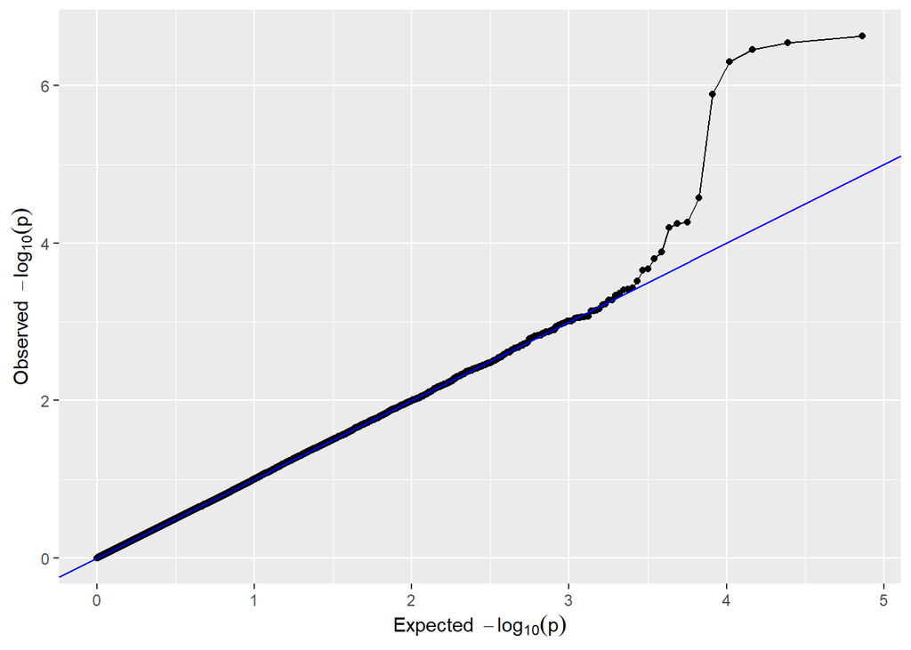

```r
## qq plot

plot(GWASdrops, plotType = "qq", trait = "grain.yield")
```

*Manhattan Plots*

These plots help to visualize which SNPs are significant for a specific phenotypic trait and which chromosomes they appear on. The plots axis’ are thus -log10(p) and the chromosome numbers + positions. Significant SNPs are marked with a different color if they fall abovethe threshold. This can be changed to visualize a wider range of potentially significant SNPs. These plots can also be modified to focus on a specific chromosome + position, LOD value, or specific SNPs with known impacts. Below are examples for grain yield.

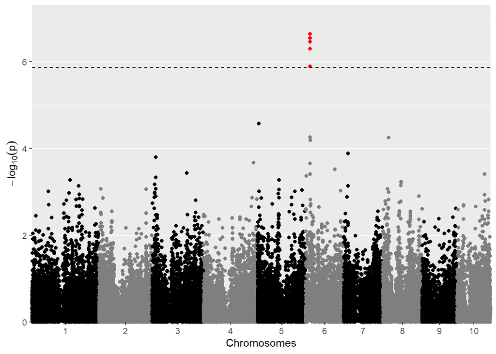

```r
#regular manhattan
plot(GWASdrops, plotType = "manhattan", trait = "grain.yield")
```

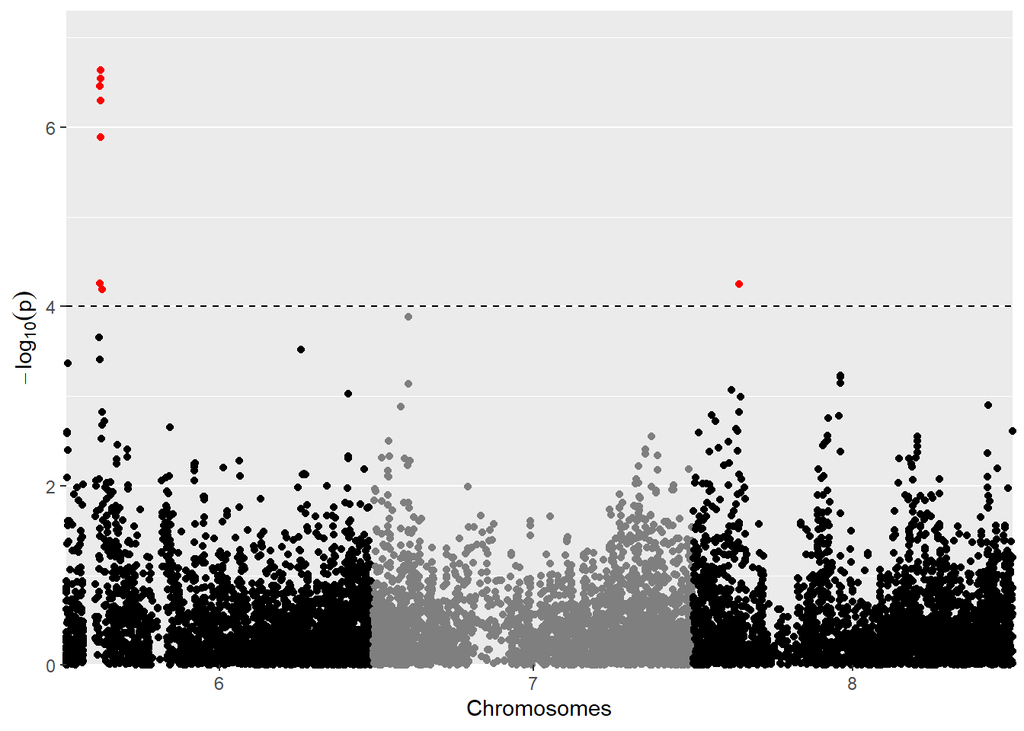

```r
# adjusted threshold + chr #
plot(GWASdrops, plotType = "manhattan", trait = "grain.yield",
     yThr = 4, chr = 6:8)
```

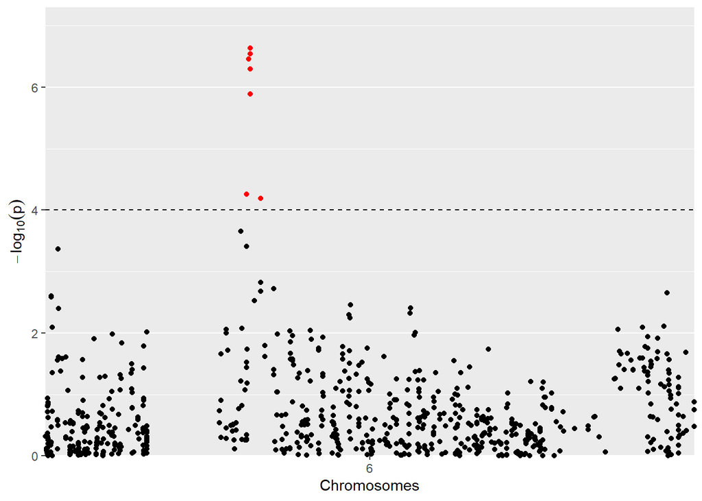

```r
#modifying chro position
plot(GWASdrops, plotType = "manhattan", trait = "grain.yield",
     yThr = 4, chr = 6, startPos = 0, endPos = 6e7)
```

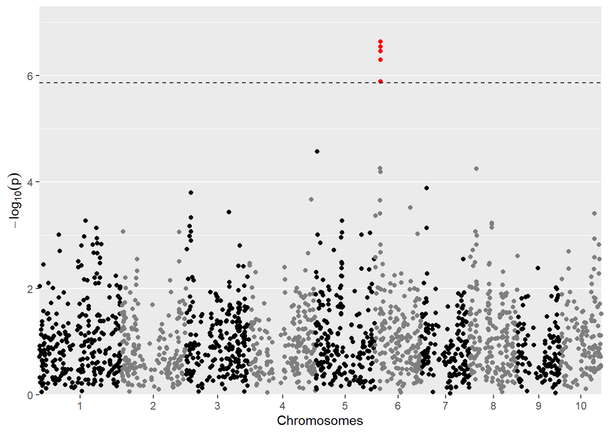

```r
#adjusted lod value - decrease # SNPs on plot
# SNPs with LOD lower than set value, only 5% will be plotted

plot(GWASdrops, plotType = "manhattan", trait = "grain.yield", lod = 3)
```

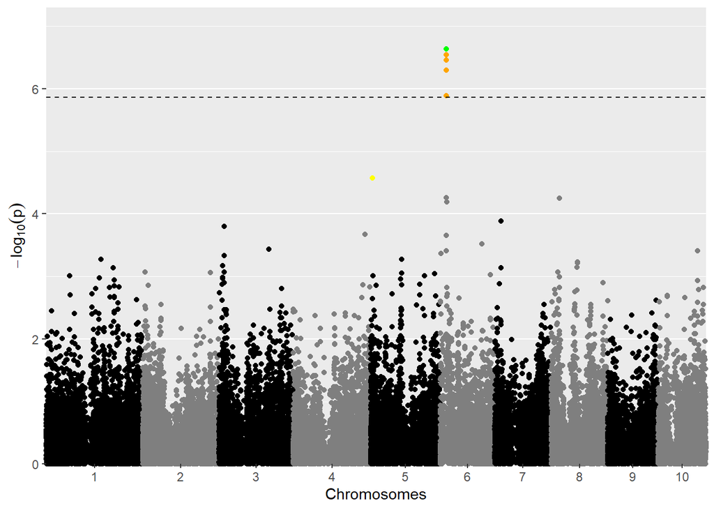

```r
#SNPs with known effects
plot(GWASdrops, plotType = "manhattan", trait = "grain.yield",
     effects = c("PZE-106021410", "PZE-105012420"))
```

```r
    # these 2 SNPs will be in different colours
```

*QTL plots*

QTL plots help to understand where significant SNPs are on the chromosomes and what their effect size is. This is a plot that can be made for multiple traits allowing you to visualize if there is any overlap in QTLs and just how significant SNPs are spread throughout the genome. The size of the circle indicates the effect size of the SNP. These plots can be adjusted similar to the manhattan plots above. Below are some examples

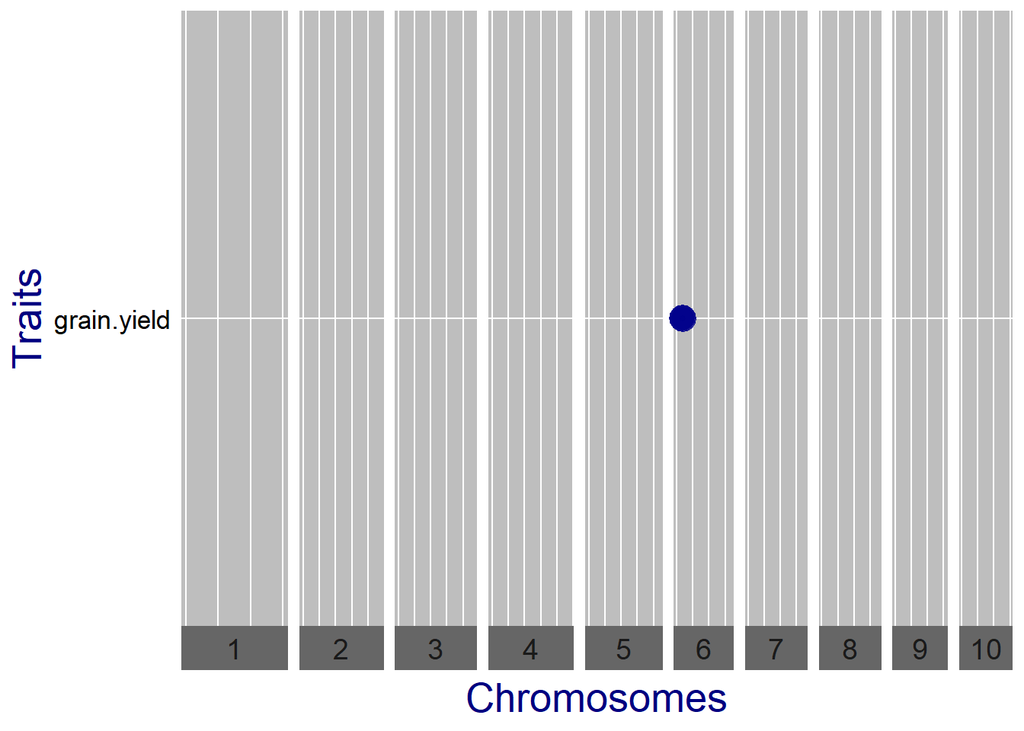

```r
plot(GWASdrops, plotType = "qtl")
```

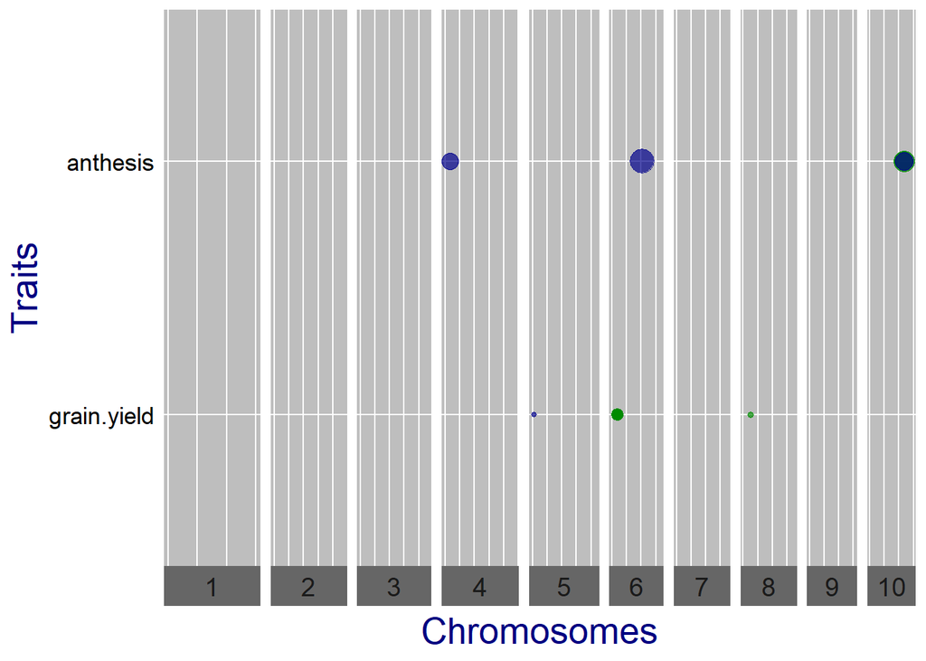

```r
#adjusting the threshold
plot(GWASdrops, plotType = "qtl", yThr = 4)
```

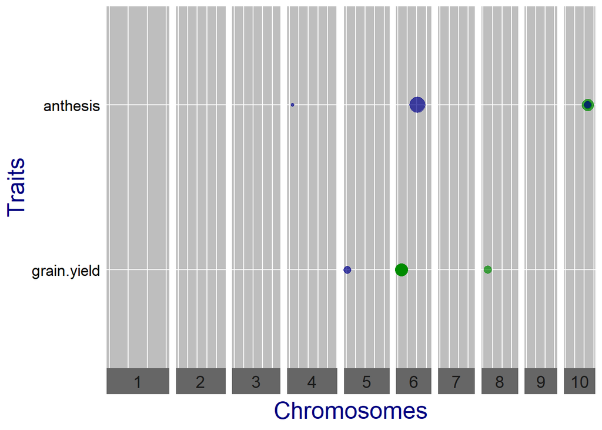

```r
# normalize by the standard deviation of the phenotype
plot(GWASdrops, plotType = "qtl", yThr = 4, normalize = TRUE)
```

```r
  #this normalizes the effect size to be relevant to the specific trait and comparable between the two
```